# Monitoring effects on Case Outcomes - New Specification

This document contains the results of the analysis of the effects of the monitoring treatment on case outcomes at the case (expediente) level. We defined two different treatments depending on the starting dates of a case, the first “treatment” (balance check) was assigned to a case if it started before the monitoring intervention (from Jan 2018 to Feb 2020); the second was assigned to a case if it started after the monitoring intervention (June 2020-Oct 2021); we leave a window of two to three months between both treatments.

## Duration of cases

```r
datasummary(
  (`Duration of cases` = length_cases) ~ # nolint
  Mean  * Arguments(fmt = "%.2f") +
  SD  * Arguments(fmt = "%.2f") +
  Min  * Arguments(fmt = "%.0f") +
  Max  * Arguments(fmt = "%.0f") +
  Median * Arguments(fmt = "%.0f") +
  1,
  fmt = 0,
  data = data_case_outcomes)
```

[output not shown]

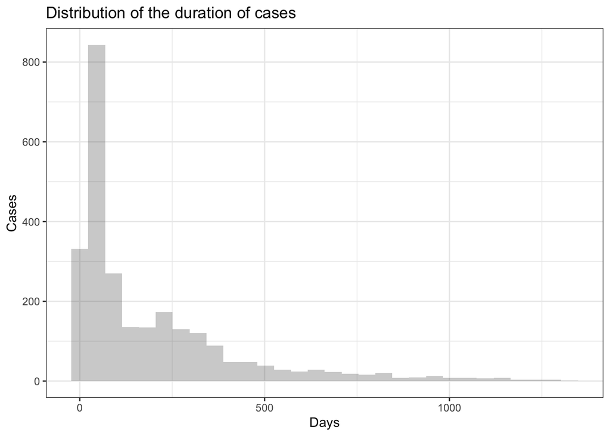

```r
ggplot(
  data_case_outcomes,
  aes(x = length_cases)) + geom_histogram(alpha = .3) +
  xlab("Days") + ylab("Cases") + ggtitle("Distribution of the duration of cases") +
  theme_bw()
```

## Case outcomes

### Appeals

```r
note <-  "Estimates are OLS. Before course regression is restricted to cases started between Jan 2018 and Feb 2020. During/after course regression is restricted to cases started between June 2020 and Oct 2021"

appeal_before <- felm(var_appeal ~ treat_partial,
  data = data_case_outcomes_bef)

appeal_during <- felm(var_appeal ~ treat_partial,
  data = data_case_outcomes_aft)


stargazer(appeal_before, appeal_during,
            type = "html",
            omit = "Constant",
            dep.var.labels = c("Decision appealed"),
            column.labels = c("Before course", "During/After course"),
            covariate.labels = "Monitoring treatment",
            notes = note)
```

|  | *Dependent variable:* |  |
| --- | --- | --- |
|  | Decision appealed |  |
|  | Before course | During/After course |
|  | (1) | (2) |
| Monitoring treatment | 0.061** | 0.486*** |
|  | (0.030) | (0.064) |
| Observations | 1,828 | 731 |
| R<sup>2</sup> | 0.002 | 0.073 |
| Adjusted R<sup>2</sup> | 0.002 | 0.072 |
| Residual Std. Error | 0.492 (df = 1826) | 0.390 (df = 729) |
| *Note:* | p<0.1; p<0.05; p<0.01 |  |
|  | Estimates are OLS. Before course regression is restricted to cases started between Jan 2018 and Feb 2020. During/after course regression is restricted to cases started between June 2020 and Oct 2021 |  |

```r
            #out=paste0(out_dir, "monitoring_case_outcomes.html"))
```

### Direction of decision

```r
note <-  "Estimates are OLS. Before course regression is restricted to cases started between Jan 2018 and Feb 2020. During/after course regression is restricted to cases started between June 2020 and Oct 2021"

fundada_before <- felm(
  var_fundada ~ treat_partial,
  data = data_case_outcomes_bef)

fundada_during <- felm(
  var_fundada ~ treat_partial,
  data = data_case_outcomes_aft)

stargazer(fundada_before, fundada_during,
            type = "html",
            omit = "Constant",
            dep.var.labels = c("Decision in favor of plaintiff"),
            column.labels = c("Before course", "During/After course"),
            covariate.labels = "Monitoring treatment",
            notes = note)
```

|  | *Dependent variable:* |  |
| --- | --- | --- |
|  | Decision in favor of plaintiff |  |
|  | Before course | During/After course |
|  | (1) | (2) |
| Monitoring treatment | -0.091*** | -0.321*** |
|  | (0.029) | (0.043) |
| Observations | 1,828 | 731 |
| R<sup>2</sup> | 0.005 | 0.070 |
| Adjusted R<sup>2</sup> | 0.005 | 0.069 |
| Residual Std. Error | 0.471 (df = 1826) | 0.263 (df = 729) |
| *Note:* | p<0.1; p<0.05; p<0.01 |  |
|  | Estimates are OLS. Before course regression is restricted to cases started between Jan 2018 and Feb 2020. During/after course regression is restricted to cases started between June 2020 and Oct 2021 |  |

```r
            #out=paste0(out_dir, "monitoring_case_outcomes.html"))
```

### Reversals

We construct the reversal variable as an indicator. Where 1 is equal to a verdict reverting the original decision of the lower court (keyword in spanish: revoca) and 0 otherwise, the sample is restricted to cases that were appealed and are in the final stages of the decision by the superior court (keywords in spanish: “sentencia”, “final”, “vista”). The monitoring intervention did not have effects during/after the treatment.

```r
note <-  "Estimates are OLS. Before course regression is restricted to cases started between Jan 2018 and Feb 2020. During/after course regression is restricted to cases started between June 2020 and Oct 2021"


revoca_before <- felm(
  var_revoca ~ treat_partial,
  data = data_case_outcomes_bef)

revoca_during <- felm(
  var_revoca ~ treat_partial,
  data = data_case_outcomes_aft)

stargazer(revoca_before, revoca_during,
            type = "html",
            omit = "Constant",
            dep.var.labels = c("Decision reversed"),
            column.labels = c("Before course", "During/After course"),
            covariate.labels = "Monitoring treatment",
            notes = note)
```

|  | *Dependent variable:* |  |
| --- | --- | --- |
|  | Decision reversed |  |
|  | Before course | During/After course |
|  | (1) | (2) |
| Monitoring treatment | -0.074 | -0.215 |
|  | (0.047) | (0.169) |
| Observations | 831 | 52 |
| R<sup>2</sup> | 0.003 | 0.031 |
| Adjusted R<sup>2</sup> | 0.002 | 0.012 |
| Residual Std. Error | 0.499 (df = 829) | 0.499 (df = 50) |
| *Note:* | p<0.1; p<0.05; p<0.01 |  |
|  | Estimates are OLS. Before course regression is restricted to cases started between Jan 2018 and Feb 2020. During/after course regression is restricted to cases started between June 2020 and Oct 2021 |  |

## Balance tables

### Full sample

The following table presents summary statistics for all experimental groups, we also include difference in means and p-values in column 6.

```r
title <- "Baseline participant characteristics, by Treatment and Control classes"

title2 <- "Baseline participant characteristics for the case outcome subsample, by Treatment and Control classes"

notes <- "Columns 1-2 and 3-4 reports average and standard deviations from participant characteristics in randomly-assigned treatment classes and control classes, respectively. Column 5 reports the estimated difference between treatment and control participant. Column 6 reports the estimated p-value."

# Rename and recode variables
md_participant <- md_participant %>%
  mutate(
    Monitoreo = ifelse(monitoreo == 1, "Treatment", "Control")) %>%
  select(
    Monitoreo,
    `Participant Judge` = participant_judge,
    `Female participant` = participant_female,
    `Participant age` = participant_age,
    `Course location` = participant_sede,
    `Participant years tenure` = participant_age,
    `Participant Level 2` = participant_level_2,
    `Participant Level 3` = participant_level_3,
    `Participant Level 4` = participant_level_4)

datasummary_balance(~Monitoreo,
                    data = md_participant,
                    title = title,
                    dinm_statistic = "p.value",
                    notes = notes,
                    fmt = 2)
```

Baseline participant characteristics, by Treatment and Control classes

|  |  | Control (N=214) Mean | Control (N=214) Std. Dev. | Treatment (N=346) Mean | Treatment (N=346) Std. Dev. | Diff. in Means | p |
| --- | --- | --- | --- | --- | --- | --- | --- |
| Participant Judge |  | 0.28 | 0.45 | 0.34 | 0.47 | 0.06 | 0.14 |
| Female participant |  | 0.43 | 0.50 | 0.34 | 0.47 | -0.10 | 0.02 |
| Participant age |  | 44.68 | 6.73 | 46.27 | 6.86 | 1.60 | 0.01 |
| Participant years tenure |  | 44.68 | 6.73 | 46.27 | 6.86 | 1.60 | 0.01 |
| Participant Level 2 |  | 0.28 | 0.45 | 0.18 | 0.39 | -0.10 | 0.01 |
| Participant Level 3 |  | 0.72 | 0.45 | 0.82 | 0.39 | 0.10 | 0.01 |
| Participant Level 4 |  | 0.00 | 0.00 | 0.00 | 0.00 | 0.00 |  |
|  |  | N | Pct. | N | Pct. |  |  |
| Course location | AREQUIPA | 42 | 19.6 | 35 | 10.1 |  |  |
|  | CUSCO | 13 | 6.1 | 15 | 4.3 |  |  |
|  | LA LIBERTAD | 28 | 13.1 | 66 | 19.1 |  |  |
|  | LAMBAYEQUE | 15 | 7.0 | 12 | 3.5 |  |  |
|  | LIMA | 103 | 48.1 | 202 | 58.4 |  |  |
|  | PIURA | 13 | 6.1 | 16 | 4.6 |  |  |

Columns 1-2 and 3-4 reports average and standard deviations from participant characteristics in randomly-assigned treatment classes and control classes, respectively. Column 5 reports the estimated difference between treatment and control participant. Column 6 reports the estimated p-value.

### Restricted (cases) sample

The following table presents summary statistics for a subset composed of all judges with cases in the peruvian court records database, we also include difference in means and p-values in column 6.

```r
md_participant_bt <- md_participant_bt %>%
  mutate(
    Monitoreo = ifelse(monitoreo == 1, "Treatment", "Control")) %>%
  select(
    Monitoreo,
    `Number of cases` = `n()`,
    `Participant Judge` = participant_judge,
    `Female participant` = participant_female,
    `Participant age` = participant_age,
    `Course location` = participant_sede,
    `Participant years tenure` = participant_age,
    `Participant Level 2` = participant_level_2,
    `Participant Level 3` = participant_level_3,
    `Participant Level 4` = participant_level_4)

datasummary_balance(~Monitoreo,
                    data = md_participant_bt,
                    title = title2,
                    dinm_statistic = "p.value",
                    notes = notes,
                    fmt = 2)
```

Baseline participant characteristics for the case outcome subsample, by Treatment and Control classes

|  |  | Control (N=16) Mean | Control (N=16) Std. Dev. | Treatment (N=41) Mean | Treatment (N=41) Std. Dev. | Diff. in Means | p |
| --- | --- | --- | --- | --- | --- | --- | --- |
| Number of cases |  | 304.75 | 411.36 | 319.05 | 489.13 | 14.30 | 0.91 |
| Participant Judge |  | 0.94 | 0.25 | 0.98 | 0.16 | 0.04 | 0.58 |
| Female participant |  | 0.75 | 0.45 | 0.46 | 0.50 | -0.29 | 0.04 |
| Participant age |  | 45.06 | 6.09 | 46.83 | 6.07 | 1.77 | 0.33 |
| Participant years tenure |  | 45.06 | 6.09 | 46.83 | 6.07 | 1.77 | 0.33 |
| Participant Level 2 |  | 0.50 | 0.52 | 0.22 | 0.42 | -0.28 | 0.06 |
| Participant Level 3 |  | 0.50 | 0.52 | 0.78 | 0.42 | 0.28 | 0.06 |
| Participant Level 4 |  | 0.00 | 0.00 | 0.00 | 0.00 | 0.00 |  |
|  |  | N | Pct. | N | Pct. |  |  |
| Course location | AREQUIPA | 0 | 0.0 | 11 | 26.8 |  |  |
|  | CUSCO | 1 | 6.2 | 1 | 2.4 |  |  |
|  | LA LIBERTAD | 2 | 12.5 | 6 | 14.6 |  |  |
|  | LAMBAYEQUE | 2 | 12.5 | 0 | 0.0 |  |  |
|  | LIMA | 9 | 56.2 | 23 | 56.1 |  |  |
|  | PIURA | 2 | 12.5 | 0 | 0.0 |  |  |

Columns 1-2 and 3-4 reports average and standard deviations from participant characteristics in randomly-assigned treatment classes and control classes, respectively. Column 5 reports the estimated difference between treatment and control participant. Column 6 reports the estimated p-value.

### Judge sample

The following table presents summary statistics for a subset composed of all judges that participated in AMAG. We also include difference in means and p-values in column 6.

```r
md_participant_judge <- md_participant_judge %>%
  mutate(
    Monitoreo = ifelse(monitoreo == 1, "Treatment", "Control")) %>%
  select(
    Monitoreo,
    `Criminal court` = judge_criminal_court,
    `Female participant` = participant_female,
    `Participant age` = participant_age,
    `Course location` = participant_sede,
    `Participant years tenure` = participant_age,
    `Participant Level 2` = participant_level_2,
    `Participant Level 3` = participant_level_3,
    `Participant Level 4` = participant_level_4)

datasummary_balance(~Monitoreo,
                    data = md_participant_judge,
                    title = title2,
                    dinm_statistic = "p.value",
                    notes = notes,
                    fmt = 2)
```

Baseline participant characteristics for the case outcome subsample, by Treatment and Control classes

|  |  | Control (N=59) Mean | Control (N=59) Std. Dev. | Treatment (N=116) Mean | Treatment (N=116) Std. Dev. | Diff. in Means | p |
| --- | --- | --- | --- | --- | --- | --- | --- |
| Criminal court |  | 0.59 | 0.50 | 0.51 | 0.50 | -0.08 | 0.32 |
| Female participant |  | 0.41 | 0.50 | 0.37 | 0.49 | -0.04 | 0.65 |
| Participant age |  | 46.61 | 5.71 | 47.56 | 5.93 | 0.95 | 0.31 |
| Participant years tenure |  | 46.61 | 5.71 | 47.56 | 5.93 | 0.95 | 0.31 |
| Participant Level 2 |  | 0.15 | 0.36 | 0.11 | 0.32 | -0.04 | 0.47 |
| Participant Level 3 |  | 0.85 | 0.36 | 0.89 | 0.32 | 0.04 | 0.47 |
| Participant Level 4 |  | 0.00 | 0.00 | 0.00 | 0.00 | 0.00 |  |
|  |  | N | Pct. | N | Pct. |  |  |
| Course location | AREQUIPA | 10 | 16.9 | 17 | 14.7 |  |  |
|  | CUSCO | 8 | 13.6 | 8 | 6.9 |  |  |
|  | LA LIBERTAD | 4 | 6.8 | 13 | 11.2 |  |  |
|  | LAMBAYEQUE | 5 | 8.5 | 2 | 1.7 |  |  |
|  | LIMA | 30 | 50.8 | 71 | 61.2 |  |  |
|  | PIURA | 2 | 3.4 | 5 | 4.3 |  |  |

Columns 1-2 and 3-4 reports average and standard deviations from participant characteristics in randomly-assigned treatment classes and control classes, respectively. Column 5 reports the estimated difference between treatment and control participant. Column 6 reports the estimated p-value.